# The Power of Visuals Using ggplot2

Sandra Pérez

# Content Overview

The following analysis uses information of the COVID-19 data. The information contains data recorded daily, with variables as continent, location (country), new and total cases, new and total deaths, population, etc.

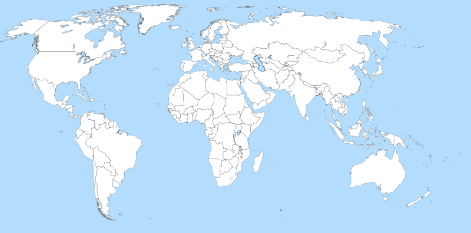

World Map

## Installing the Package

The easiest way to get ggplot2 is to install the whole tidyverse: install.packages(“tidyverse”)

Alternatively, install just ggplot2: install.packages(“ggplot2”)

Or the development version from GitHub: install.packages(“devtools”)

devtools::install_github(“tidyverse/ggplot2”)

Sometimes, it is easier to follow visual instrucions, therefore there is a great YouTube video that will guide us to install this package, step by step: * [ggplot2 Tutorial](https://www.youtube.com/watch?v=hr2X7rmkprM)

## ggplot2

The ggplot2 package, created by Hadley Wickham, offers a powerful graphics language for creating elegant and complex plots. ggplot2 is a plotting package that makes it simple to create complex plots from data in a data frame. It provides a more programmatic interface for specifying what variables to plot, how they are displayed, and general visual properties.

This package contains many functions to create differnt types of graphics. These ones are very popular: – geom_bar() - to create bar plots

– geom_line() - to create line plots

– geom_density() - to create a density chart

– geom_point() - the point geom is used to create scatterplots

Rstudio created Cheat Sheet with information about Data Visualization with ggplot2. We can visit this page: * [ggplot2-cheatsheet](https://rstudio.com/wp-content/uploads/2015/03/ggplot2-cheatsheet.pdf)

# Our Data

This table show some of the content of the dataset we are using. We will be using the columns Continent, date, new_cases, and new_deaths mainly.

```r
head (new.table.2)
```

| iso_code | continent | location | date | total_cases | new_cases | new_cases_smoothed | total_deaths | new_deaths | new_deaths_smoothed | total_cases_per_million | new_cases_per_million | new_cases_smoothed_per_million | total_deaths_per_million | new_deaths_per_million | new_deaths_smoothed_per_million | reproduction_rate | icu_patients | icu_patients_per_million | hosp_patients | hosp_patients_per_million | weekly_icu_admissions | weekly_icu_admissions_per_million | weekly_hosp_admissions | weekly_hosp_admissions_per_million | new_tests | total_tests | total_tests_per_thousand | new_tests_per_thousand | new_tests_smoothed | … |
| --- | --- | --- | --- | --- | --- | --- | --- | --- | --- | --- | --- | --- | --- | --- | --- | --- | --- | --- | --- | --- | --- | --- | --- | --- | --- | --- | --- | --- | --- | --- |
| AFG | Asia | Afghanistan | 2020-02-24 | 5 | 5 | NA | NA | NA | NA | 0.126 | 0.126 | NA | NA | NA | NA | NA | NA | NA | NA | NA | NA | NA | NA | NA | NA | NA | NA | NA | NA | … |
| AFG | Asia | Afghanistan | 2020-02-25 | 5 | 0 | NA | NA | NA | NA | 0.126 | 0.000 | NA | NA | NA | NA | NA | NA | NA | NA | NA | NA | NA | NA | NA | NA | NA | NA | NA | NA | … |
| AFG | Asia | Afghanistan | 2020-02-26 | 5 | 0 | NA | NA | NA | NA | 0.126 | 0.000 | NA | NA | NA | NA | NA | NA | NA | NA | NA | NA | NA | NA | NA | NA | NA | NA | NA | NA | … |
| AFG | Asia | Afghanistan | 2020-02-27 | 5 | 0 | NA | NA | NA | NA | 0.126 | 0.000 | NA | NA | NA | NA | NA | NA | NA | NA | NA | NA | NA | NA | NA | NA | NA | NA | NA | NA | … |
| AFG | Asia | Afghanistan | 2020-02-28 | 5 | 0 | NA | NA | NA | NA | 0.126 | 0.000 | NA | NA | NA | NA | NA | NA | NA | NA | NA | NA | NA | NA | NA | NA | NA | NA | NA | NA | … |
| AFG | Asia | Afghanistan | 2020-02-29 | 5 | 0 | 0.714 | NA | NA | 0 | 0.126 | 0.000 | 0.018 | NA | NA | 0 | NA | NA | NA | NA | NA | NA | NA | NA | NA | NA | NA | NA | NA | NA | … |

## Example 1: Table vs Bars Graphic

We group our information by continent to find out how many cases per continent. We use the commands group_by and summarize.

```r
# New cases and new deaths per continent
new.table.2 %>%

 group_by (continent) %>%

 summarize (new.cases = round(sum(new_cases, na.rm = TRUE)),
             new.deaths = round(sum(new_deaths, na.rm = TRUE)))
```

| continent | new.cases | new.deaths |
| --- | --- | --- |
| Africa | 8374299 | 213212 |
| Asia | 75927962 | 1138687 |
| Europe | 60745285 | 1242672 |
| North America | 53119972 | 1074040 |
| Oceania | 200415 | 2326 |
| South America | 37776098 | 1146660 |

```r
# New cases per continent bars graphic

new.table.2 %>%

 group_by (continent) %>%

 summarize(total.cases = sum(new_cases, na.rm = TRUE),
            total.deaths = sum(new_deaths, na.rm = TRUE), .groups = 'drop')
```

| continent | total.cases | total.deaths |
| --- | --- | --- |
| Africa | 8374299 | 213212 |
| Asia | 75927962 | 1138687 |
| Europe | 60745285 | 1242672 |
| North America | 53119972 | 1074040 |
| Oceania | 200415 | 2326 |
| South America | 37776098 | 1146660 |

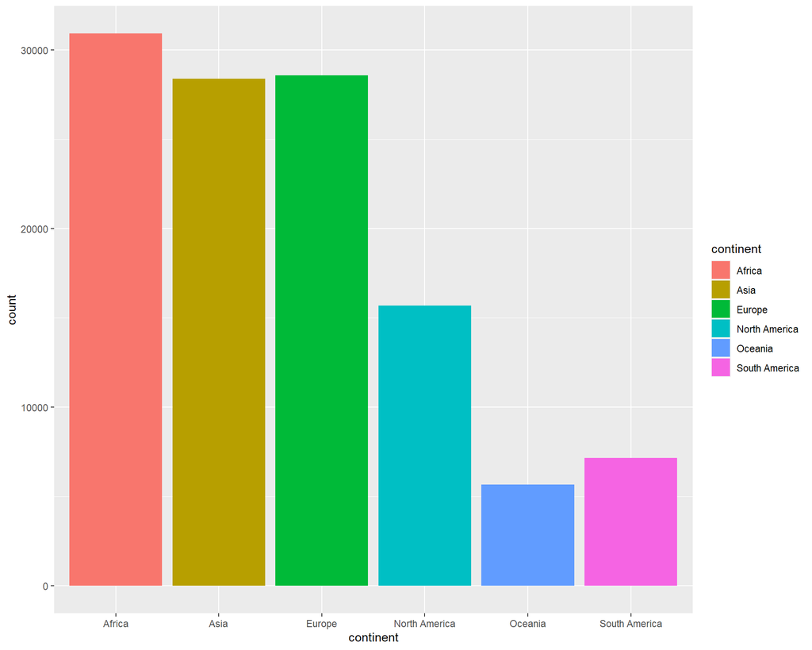

```r
 ggplot (new.table.2,
         aes(x = continent,
         fill = continent)) +
         geom_bar()
```

## Example 2: Table vs Plot

We group our information by date and continent to find out how many each continenthad every day. We use the commands group_by and summarize again.

```r
# New cases per date and continent lines graphic

new.table.2 %>%

  group_by (date, continent) %>%

  summarize (cases.per.date  = mean (new_cases), .groups = 'drop')
```

| date | continent | cases.per.date |
| --- | --- | --- |
| 2020-01-01 | North America | NA |
| 2020-01-01 | South America | NA |
| 2020-01-02 | North America | NA |
| 2020-01-02 | South America | NA |
| 2020-01-03 | North America | NA |
| 2020-01-03 | South America | NA |
| 2020-01-04 | Asia | NA |
| 2020-01-04 | North America | NA |
| 2020-01-04 | South America | NA |
| 2020-01-05 | Asia | NA |

[output cut: 3780 more lines]

Again the same information from the table but using a visual. We will be using the ggplot() again, the geom_line(), and the geom_point() functions. The color of the lines and points will be determined by the continent variable.

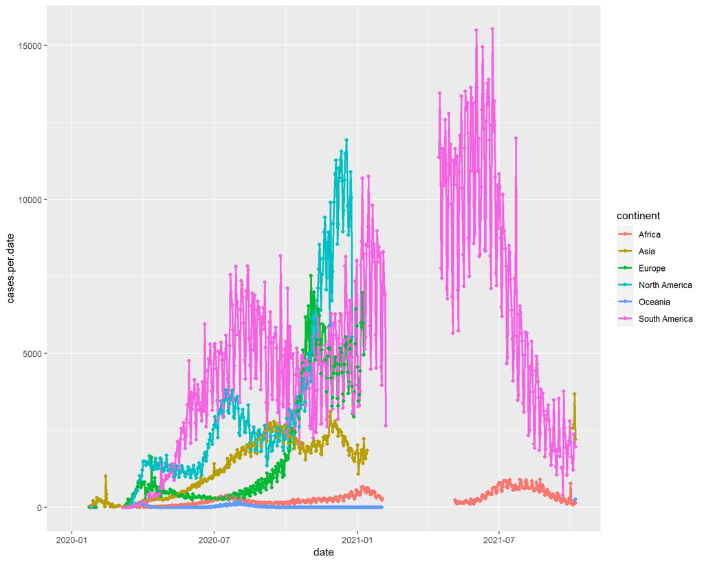

```r
# New cases per date and continent lines graphic

new.table.2 %>%

  group_by (date, continent) %>%

  summarize (cases.per.date  = mean (new_cases), .groups = 'drop') %>%

  ggplot (aes(x = date,
              y = cases.per.date,
              color = continent)) +

  geom_line (size=1) +

  geom_point (size=1.5)
```

## A Dynamic Graphic

The ggplot() allows us to make a dynamic visualization. We just need to use the transition_reveal() function with the date variable. Using the ggplot() will make an elegant graphic!

[figure not shown]

```r
# New cases per date and continent lines dynamic graphic

new.table.2 %>%

  group_by (date, continent) %>%

  summarize (cases.per.date  = mean (new_cases), .groups = 'drop') %>%

  ggplot (aes(x = date,
              y = cases.per.date,
              color = continent)) +

  geom_line (size=1) +

  transition_reveal(date)
```

```r
#  geom_point (size=1.5)
```

## Example 3: Another Cool Graphic

```r
# density graphic


new.table.2 %>%

  group_by (continent, aged_65_older) %>%

  summarize (average.aged.65.older  = mean (aged_65_older), .groups = 'drop')
```

| continent | aged_65_older | average.aged.65.older |
| --- | --- | --- |
| Africa | 2.168 | 2.168 |
| Africa | 2.339 | 2.339 |
| Africa | 2.405 | 2.405 |
| Africa | 2.409 | 2.409 |
| Africa | 2.480 | 2.480 |
| Africa | 2.486 | 2.486 |
| Africa | 2.519 | 2.519 |
| Africa | 2.538 | 2.538 |
| Africa | 2.553 | 2.553 |
| Africa | 2.562 | 2.562 |

[output cut: 184 more lines]

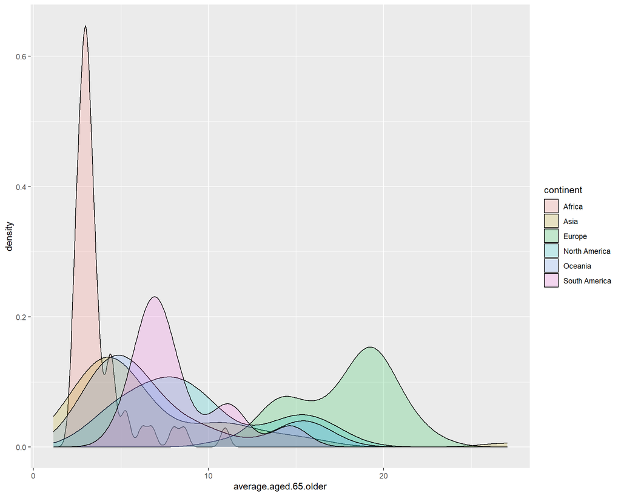

```r
# density graphic


new.table.2 %>%

  group_by (continent, aged_65_older) %>%

  summarize (average.aged.65.older  = mean (aged_65_older), .groups = 'drop') %>%

  ggplot (aes(x = average.aged.65.older,
           fill = continent)) +

  geom_density(alpha=0.2)
```

# Further Resources

Learn more about ggplot() with the following link: [ggplot2: Create Elegant Data Visualisations Using the Grammar of Graphics](https://cran.r-project.org/web/packages/ggplot2/index.html)

- Resource I [Coronavirus Source Data](https://ourworldindata.org/coronavirus-source-data)

# Works Cited

This code through references and cites the following sources:

- DeltaDNA (2015). Source I. [Gorgeous graphs with ggplot2](https://www.youtube.com/watch?v=rsG-GgR0aEY)
- Earth Lab (2021). Source II. [Earth Data Analytics Online Certificate](https://www.earthdatascience.org/courses/earth-analytics/document-your-science/add-images-to-rmarkdown-report/)